# Methodology

| Number of Children | Months Since Marriage | Count by Age at Marriage | Count by Literate or Illiterate |
| --- | --- | --- | --- |
| Min: 0 | Min: 0.0 | At 0-15: 52 | Literate: 4567 |
| 1st Qu: 1 | 1st Qu: 73.0 | At 15-18: 452 | Illiterate: 581 |
| Median: 2 | Median: 148.0 | At 18-20: 910 |  |
| Mean: 2 | Mean: 155.2 | At 20-22: 1126 |  |
| 3rd Qu: 3 | 3rd Qu: 230.0 | At 22-25: 1468 |  |
| Max: 17 | Max: 431.0 | At 25-30: 923 |  |
|  |  | At over 30: 217 |  |

因此我们的模型是：

$$\begin{align*}
\log(E[\text{Children}_i]) =& \beta_0 + \beta_1 \text{M}_{0to15}(i)
+ \beta_2 \text{M}_{15to18}(i) + \\ &\beta_3 \text{M}_{18to20}(i)
+ \beta_4 \text{M}_{20to22}(i) + \beta_5 \text{M}_{25to30}(i) + \\
&\beta_6 \text{M}_{30toInf}(i) + \beta_8 \text{Literacy}_{i} + \\
&\log(\text{Months}_{i}) + \epsilon_i
\end{align*}$$
$$\begin{align*}
\textbf{Where:} &\\
\text{Children}_i & : \text{ The total number of children born
to the } i\text{th individual.} \\
M_{a\text{to} b}(i) & : \text{ Binary indicator variable, taking
the value of } 1 \text{ if the } i\text{th individual } \\
& \quad \text{entered into marriage between ages } a \text{ and
} b, \text{ and } 0 \text{ otherwise.} \\
\text{Literacy}_i & : \text{ Binary indicator variable, equal to
} 1 \text{ if the } i\text{th individual is illiterate,} \\
& \quad \text{and } 0 \text{ otherwise.} \\
\text{Months}_i & : \text{ The total duration of marriage (in
months) for the } i\text{th individual.} \\
\beta_0, \beta_1, \dots, \beta_8 & : \text{ Coefficients
estimated in the regression model.} \\
\epsilon_i & : \text{ Stochastic error term capturing unobserved
heterogeneity and random fluctuations.}
\end{align*}$$

```r
possi_model <- glm(children ~ ageMarried + literacy ,
                 family = poisson(link = "log"),
                 data = portugal,
                 offset = log(pmax(1, portugal$monthsSinceM)/12))
```

在确定最初的模型之后，我们对模型的检验进行了检测。我们首先通过观察@fig-qqplot, 我们发现most of the residuals closely follow the reference line, indicating that the deviance residuals are approximately normally distributed. This suggests that the Poisson model is a reasonable fit for the data and confirms that the model satisfies the assumption that the log-mean of the response variable has a linear relationship with the predictor variables. 然后我们计算了dispersion parameter $\hat{\phi}$:

$$\begin{align*}
\hat{\phi} = \frac{\sum (\text{Pearson residuals})^2}{\text{Degrees of
Freedom for Pearson Residuals}} = \frac{5600.133}{5140} = 1.08952
\approx 1
\end{align*}$$

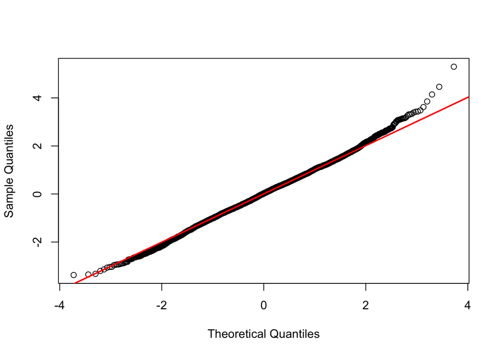

QQ-Plot of The Final Model

```
## [1] 5600.133
```

```
## [1] 5140
```

```
## [1] 1.08952
```

```r
possi_model_ci <- as.data.frame(exp(confint(possi_model)[-1,]))
```

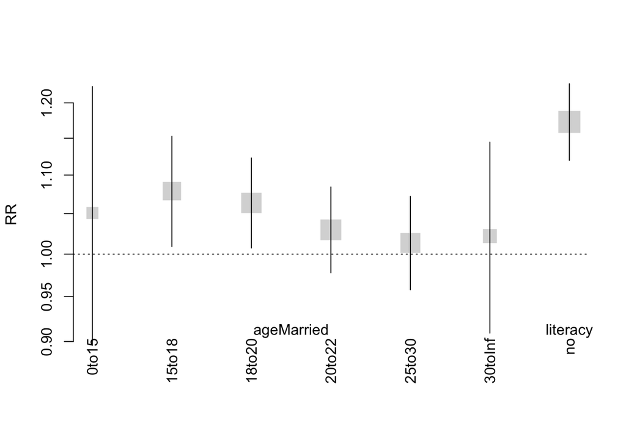

```r
possi_model_ci$level = gsub(paste(names(possi_model$xlevels), collapse='|'),
   "", rownames(possi_model_ci))
possi_model_ci$variable=unlist(strsplit(rownames(possi_model_ci),possi_model_ci$level))
possi_model_ci$x = 1:nrow(possi_model_ci)
possi_model_ci$cex = sqrt(1/apply(log(possi_model_ci[,1:2]),1,diff))
forXaxis = tapply(possi_model_ci$x, possi_model_ci$variable, mean)

matplot(possi_model_ci[,1:2], type='n',
   xaxt='n', bty='n', xaxt='n',
   log='y', ylab='RR')

segments(possi_model_ci$x, possi_model_ci[,1],
   possi_model_ci$x, possi_model_ci[,2])

 points(possi_model_ci$x,
   exp(possi_model$coef[-1]), pch=15,
   cex = possi_model_ci$cex, col = '#00000030')

mtext(possi_model_ci$level, 1, at=possi_model_ci$x,
   las=3, line=-1)

mtext(names(forXaxis), 1, at=forXaxis,
   line=-2)
abline(h=1, lty=3)
```

```r
knitr::kable(summary(possi_model)$coef, digits = 3)
```

|  | Estimate | Std. Error | z value | Pr(>\|z\|) |
| --- | --- | --- | --- | --- |
| (Intercept) | -1.802 | 0.018 | -99.076 | 0.000 |
| ageMarried0to15 | 0.050 | 0.080 | 0.624 | 0.533 |
| ageMarried15to18 | 0.076 | 0.034 | 2.236 | 0.025 |
| ageMarried18to20 | 0.062 | 0.028 | 2.228 | 0.026 |
| ageMarried20to22 | 0.029 | 0.026 | 1.105 | 0.269 |
| ageMarried25to30 | 0.013 | 0.029 | 0.468 | 0.640 |
| ageMarried30toInf | 0.022 | 0.059 | 0.369 | 0.712 |
| literacyno | 0.159 | 0.024 | 6.770 | 0.000 |

```r
nbinom_model <- glmmTMB(children ~ ageMarried + literacy ,
                 family = nbinom2,
                 data = portugal,
                 offset = log(pmax(1, portugal$monthsSinceM)/12))
```

```r
knitr::kable(
   rbind(confint(nbinom_model)[1:7,c(3,1,2)],
 sd=1/sqrt(confint(nbinom_model, parm='sigma'))[c(3,1,2)]), digits=3)
```

|  | Estimate | 2.5 % | 97.5 % |
| --- | --- | --- | --- |
| (Intercept) | -1.783 | -1.822 | -1.744 |
| ageMarried0to15 | 0.068 | -0.109 | 0.244 |
| ageMarried15to18 | 0.084 | 0.009 | 0.158 |
| ageMarried18to20 | 0.069 | 0.009 | 0.129 |
| ageMarried20to22 | 0.035 | -0.022 | 0.092 |
| ageMarried25to30 | 0.011 | -0.051 | 0.072 |
| ageMarried30toInf | 0.021 | -0.102 | 0.144 |
| sd | 0.265 | 0.298 | 0.235 |